# Planning vs Searching

Ernesto Carrella

July 22, 2016

Currently fishers choose where to go by the explore-exploit algorithm. The fisher tries new spots at random and sticks with them whenever they make more money. In AI this is a (local) **search**.  
The key feature of a search is that the options are “atoms”: nothing more is known about them and are, a priori, identical.

The alternative approach is to expand each option into a set of properties and use them to make a better choice. In AI this is called **planning**.  
For example each spot could be split into properties like “distance to port”, “habitat” or even “biomass here”. The the fisher decides where to fish by picking the spot with the best factors.

Planning is potentially more efficient as it gives fishers more dimensions over which to make their decisions. Its main draw-back is that it needs more information (what the properties are) and more model-knowledge (how to put properties together to make a decision). If some information is lacking or the model-knowledge is limited then fisher chooses sub-optimality and fails to adapt. We are hard-wiring what the fisher looks for and how it puts it together and its response will depend on the quality of this wiring.

## Oil prices

Take the [usual gas price changes example](http://carrknight.github.io/poseidon/gaslocation/gaslocation.html). Fishers go fishing far from port, gas price goes up, fishers change their best spot to somewhere closer. We already know that the explore-exploit algorithm works fine in this scenario.

However the adaptation trajectory is a bit iffy. When the price of gas goes up the fishers do not react immediately. Only after some agents randomly try fishing closer to port the fleet starts progressing toward the new best spot.

Now compare this with a (perfect) planner agent. Rather than treating each fishing spot as a black-box the planner knows the properties of each possible option. It knows its distance from port, it knows how much fish there is and how much time it takes to get there. It can compute the expected profit per hour for each possible spot and pick the one with the highest profits.

Imagine the gas price goes up. The perfect planner puts the new gas price in its profit function and immediately knows the new best spot. The adaptation is instantaneous.

This can be seen in the next figure. I run the same simulation with explore-exploit fishers and with perfect planning fishers. At a specific date I raise the gas price and check the effect on the average distance from port fished. For the planner the reaction is immediate. The explore-exploit adaptation takes time.

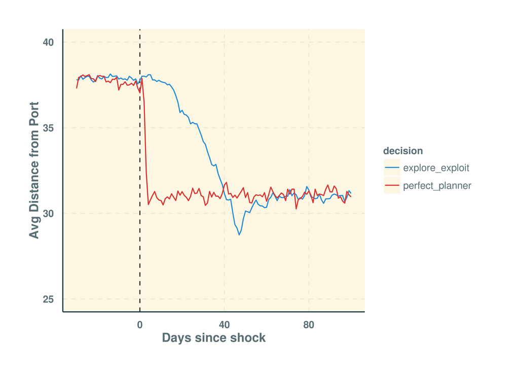

You can also see this in a video. Imagine there are 100 fishers, 50 are explore-exploit (the blue boats), 50 are perfect planners (the red boats). Every few weeks I change the gas price from 0 to 8 (and viceversa). Whenever price changes the planners (in red) immediately go to the new best spot, while the explore-exploit ones (in blue) are always taken by surprise and need a bit of time to find where to go next.

[video not shown]

## Imperfect Planning

The planner we have now has two kinds of knowledge. First, it has model knowledge: it knows how changes in gas price and biomass affect profits. Second, it has state knowledge: it knows the biomass distribution in each cell. That’s a bit too much of an assumption however, as now the fisher is all-knowing and never wrong.

In particular we would like the agent to have model knowledge but learn about the state of the world only through experience. This means implementing some form of machine learning algorithm. The result is an agent who is a planner but on limited information. As it explores this information improves and the decisions get better. The whole work on heatmaps from the previous weeks and the Jens bayes structure are just different learning paradigms.

Now the bad news is that learning processes are quite finicky. Even small changes in parameters matter a lot and the more things one consider (habitat, season, friends and so on) the slower the model gets. For example if we use here the nearest neighbor regression we get the following adaptation to the shock:

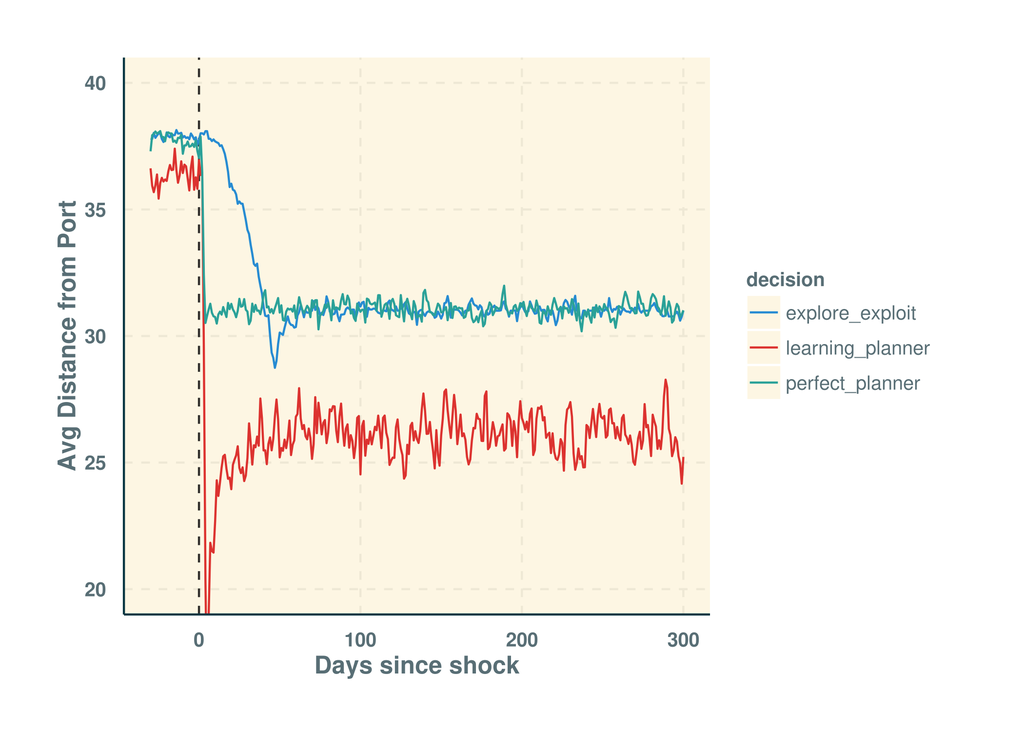

Like a planner, a price hike is reacted to immediately. However the reaction is not correct as the agent fishes too close to port compared to the perfectly informed planner. The problem is partially due to having to fish in a new area the agent doesn’t know well and it takes time to learn about it. However even in the long run the fisher ends up fishing a little too close to port. This is due to the difficulty of quantifying and dealing with uncertainity. The planning algorithm prefers fishing closer to port since it consumes less gass so that if there is even a little bit of uncertainty in the regression results the agent will choose to fish a little too close than what is optimal.

This can be shown in a video again. Same set up as before, now the light orange boats are imperfect planners. As you can see the imperfect planner also adapts quickly and mostly correctly to the change in gas prices. However whenever planners deviate from the best spot it tends to be by fishing even closer to port, never further. This is again a result of the model-knowledge acting over imperfect information and resulting in a biased outcome.

[video not shown]